# Predictive analytics and machine learning in R

Myffy

1/3/2017

Data used to build predictive model Default of Credit Card Clients in Tiawan https://archive.ics.uci.edu/ml/machine-learning-databases/00350/ Paper for Background : Yeh, I. C., & Lien, C. H. (2009). The comparisons of data mining techniques for the predictive accuracy of probability of default of credit card clients. Expert Systems with Applications, 36(2), 2473-2480.

Read in data and view

```r
#credit<- read.csv("~/default of credit card clients.csv")
#summary(credit)
str(credit)
```

```
## 'data.frame':    30000 obs. of  25 variables:
##  $ ID                        : int  1 2 3 4 5 6 7 8 9 10 ...
##  $ LIMIT_BAL                 : int  20000 120000 90000 50000 50000 50000 500000 100000 140000 20000 ...
##  $ SEX                       : int  2 2 2 2 1 1 1 2 2 1 ...
##  $ EDUCATION                 : int  2 2 2 2 2 1 1 2 3 3 ...
##  $ MARRIAGE                  : int  1 2 2 1 1 2 2 2 1 2 ...
##  $ AGE                       : int  24 26 34 37 57 37 29 23 28 35 ...
##  $ PAY_0                     : int  2 -1 0 0 -1 0 0 0 0 -2 ...
##  $ PAY_2                     : int  2 2 0 0 0 0 0 -1 0 -2 ...
##  $ PAY_3                     : int  -1 0 0 0 -1 0 0 -1 2 -2 ...
##  $ PAY_4                     : int  -1 0 0 0 0 0 0 0 0 -2 ...
##  $ PAY_5                     : int  -2 0 0 0 0 0 0 0 0 -1 ...
##  $ PAY_6                     : int  -2 2 0 0 0 0 0 -1 0 -1 ...
##  $ BILL_AMT1                 : int  3913 2682 29239 46990 8617 64400 367965 11876 11285 0 ...
##  $ BILL_AMT2                 : int  3102 1725 14027 48233 5670 57069 412023 380 14096 0 ...
##  $ BILL_AMT3                 : int  689 2682 13559 49291 35835 57608 445007 601 12108 0 ...
##  $ BILL_AMT4                 : int  0 3272 14331 28314 20940 19394 542653 221 12211 0 ...
##  $ BILL_AMT5                 : int  0 3455 14948 28959 19146 19619 483003 -159 11793 13007 ...
##  $ BILL_AMT6                 : int  0 3261 15549 29547 19131 20024 473944 567 3719 13912 ...
##  $ PAY_AMT1                  : int  0 0 1518 2000 2000 2500 55000 380 3329 0 ...
##  $ PAY_AMT2                  : int  689 1000 1500 2019 36681 1815 40000 601 0 0 ...
##  $ PAY_AMT3                  : int  0 1000 1000 1200 10000 657 38000 0 432 0 ...
##  $ PAY_AMT4                  : int  0 1000 1000 1100 9000 1000 20239 581 1000 13007 ...
##  $ PAY_AMT5                  : int  0 0 1000 1069 689 1000 13750 1687 1000 1122 ...
##  $ PAY_AMT6                  : int  0 2000 5000 1000 679 800 13770 1542 1000 0 ...
##  $ default.payment.next.month: int  1 1 0 0 0 0 0 0 0 0 ...
```

Data summary. Note the reverse of logical month series.

This research aimed at the case of customer default payments in Taiwan and builds a predictive model for probability of default. This research employed a binary variable, default payment (Yes = 1, No = 0), as the response variable. This study reviewed the literature and used the following 23 variables as explanatory variables:

X1: Amount of the given credit (NT dollar): it includes both the individual consumer credit and his/her family (supplementary) credit.

X2: Gender (1 = male; 2 = female).

X3: Education (1 = graduate school; 2 = university; 3 = high school; 4 = others).

X4: Marital status (1 = married; 2 = single; 3 = others).

X5: Age (year).

X6 - X11: History of past payment. We tracked the past monthly payment records (from April to September, 2005) as follows: X6 = the repayment status in September, 2005; X7 = the repayment status in August, 2005; . . .;X11 = the repayment status in April, 2005. The measurement scale for the repayment status is: -1 = pay duly; 1 = payment delay for one month; 2 = payment delay for two months; . . .; 8 = payment delay for eight months; 9 = payment delay for nine months and above.

X12-X17: Amount of bill statement (NT dollar). X12 = amount of bill statement in September, 2005; X13 = amount of bill statement in August, 2005; . . .; X17 = amount of bill statement in April, 2005.

X18-X23: Amount of previous payment (NT dollar). X18 = amount paid in September, 2005; X19 = amount paid in August, 2005; . . .;X23 = amount paid in April, 2005.

First we must re-order the varibles in a more logical order for computation, then re-lable them for better understanding.

```r
credit2 <- credit[c(1:6,12,11,10,9,8,7,18,17,16,15,14,13,24,23,22,21,20,19, 25)]
names(credit2)[7:25] <- c( "PAY_April","PAY_May","PAY_June","PAY_July","PAY_Aug", "PAY_Sept","BILL_AMT_April",
                           "BILL_AMT_May", "BILL_AMT_June", "BILL_AMT_July", "BILL_AMT_Aug", "BILL_AMT_Sept" ,
                           "PAY_AMT_April" , "PAY_AMT_May" , "PAY_AMT_June"  ,"PAY_AMT_July" , "PAY_AMT_Aug" ,
                           "PAY_AMT_Sept","default")
names(credit2)
```

```
##  [1] "ID"             "LIMIT_BAL"      "SEX"            "EDUCATION"
##  [5] "MARRIAGE"       "AGE"            "PAY_April"      "PAY_May"
##  [9] "PAY_June"       "PAY_July"       "PAY_Aug"        "PAY_Sept"
## [13] "BILL_AMT_April" "BILL_AMT_May"   "BILL_AMT_June"  "BILL_AMT_July"
## [17] "BILL_AMT_Aug"   "BILL_AMT_Sept"  "PAY_AMT_April"  "PAY_AMT_May"
## [21] "PAY_AMT_June"   "PAY_AMT_July"   "PAY_AMT_Aug"    "PAY_AMT_Sept"
## [25] "default"
```

Feature engineering:

Now we can brainstorm about generting predictive features out of the available features. There are also algorthims that will generate features. rather than generating thousands of useless varibles, I like ot use domain knowldege to generate the most likely uselful combinations of features. adding, subtrating, multiply/divide and exponents/logs are a great place to start.

Features to test:

1. Did the payment increase or decrease in the most recent month? (Sept payment- Aug payment)
2. What percentage of the overall balence was paid in August?
3. What percentage of the overall balence was paid in Sept?

```r
#feature: credit card balence in September
credit2$last_month <- (credit2$PAY_AMT_Sept-credit2$PAY_AMT_Aug)
credit2$percent_pay_aug <- ifelse(credit2$BILL_AMT_Sept==0,0,(credit2$PAY_AMT_Aug/credit2$BILL_AMT_Sept))
credit2$percent_pay_sept <- ifelse(credit2$BILL_AMT_Sept==0,0,(credit2$PAY_AMT_Sept/credit2$BILL_AMT_Sept))
#also will convert numeric (integer) varibles which are really categorical into factors
credit2$SEX <-as.factor(credit2$SEX )
credit2$EDUCATION <- as.factor(credit2$EDUCATION)
credit2$MARRIAGE  <- as.factor(credit2$MARRIAGE)
credit2$default  <- as.factor(credit2$default)
```

Correlation of features (can alter model performance, variable autocorrelations are important to understand)

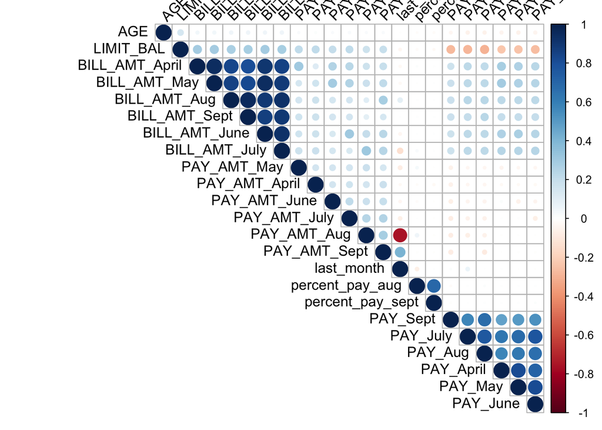

```r
#varibles with p> 0.01 are left blank. Only significant correlations are shown in color. Color intensity is proportional to the correlation coefficient.
#library(corrplot)
res <- cor(credit2[, c(2,6:24,26:28)])
#round(res, 2)
plot1<-corrplot(res, type = "upper", order = "hclust",
         tl.col = "black", tl.srt = 45)
```

Create training (60%), CV (20%), and test (20%) datasets

```r
smp_size <- floor(0.6 * nrow(credit2))
## set the seed to make your partition reproductible
set.seed(345)
train_ind <- sample(seq_len(nrow(credit2)), size = smp_size)
train <- credit2[train_ind, ]
split <- credit2[-train_ind, ]

smp_size2 <- floor(0.5 * nrow(split))
## set the seed to make your partition reproductible, change seed to get different data partitions
set.seed(456)
train_ind2 <- sample(seq_len(nrow(split)), size = smp_size2)
CV <- split[train_ind2, ]
test <- split[-train_ind2, ]

train<- train[c(2:28)]
CV<- CV[c(2:28)]
test<- test[c(2:28)]
```

Lets try the Random forest model on the data and loop over all possible values of mtry (#of parameters in the model) The number of trees can also be looped. I have chosed only 100 trees to save on computation time.

```r
#library(randomForest)
#library(ROCR)

#for(i in 1:26){   #using for loop to loop over mtry values
set.seed(123)  #use set.seed to get a reproducible RF model
#RandomForestROC <- function (y1, y2, train, testset)
#bag = randomForest(as.factor(default) ~., data=train, mtry=i, ntree=100, importance=TRUE)
# type="prob" generates probabilities instead of class labels
#randomForest generates probabilities for both the class labels, therfore
#we are selecting one of the value [2] which selects the correct probability
bag.pr = predict(bag, type="prob",newdata=CV)[,2]
#prediction is ROCR function
bag.pred = prediction(bag.pr, CV$default)
#performance in terms of true and false positive rates
bag.perf = performance(bag.pred,"tpr","fpr")
auc <- performance(bag.pred ,"auc");auc <- unlist(slot(auc, "y.values")); auc<-max(round(auc, digits = 4));
print(paste(c("AUC =",auc,"mtry=",i)))
```

```
## [1] "AUC ="  "0.7614" "mtry="  "26"
```

```r
#}
```

Now we can look at variable importance and try to create the most parsimonious (fewest varibles with best performance) model

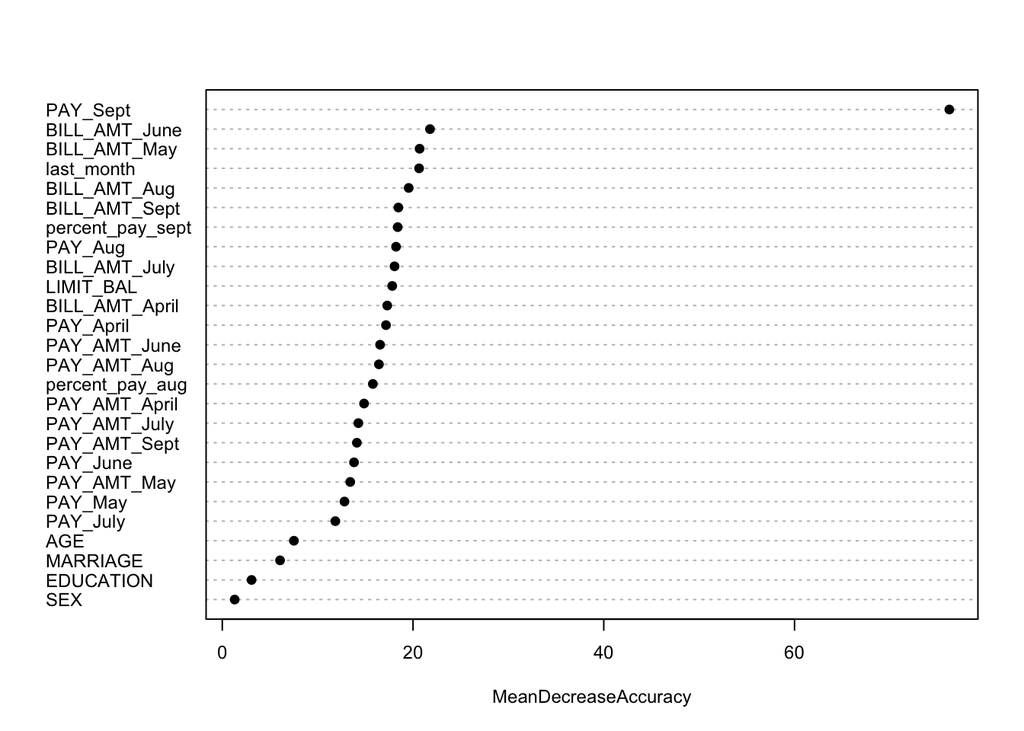

```r
#importance(bag)
#quartz()
varImpPlot(bag, type=1, pch=19, col=1, cex=0.75, main="")
```

Lower performing variables can be removed, and model performance can be tested; many interations can result

```r
#for example:
train2<- train[c(1,4:5,11,17:27)]
CV2<- CV[c(1,4:5,10:12,17:27)]
test2<- test[c(1,4:5,10:12,17:27)]
```

Now lets look at the ROC curve to dertermine fit and best probability cutoff for the model prediction

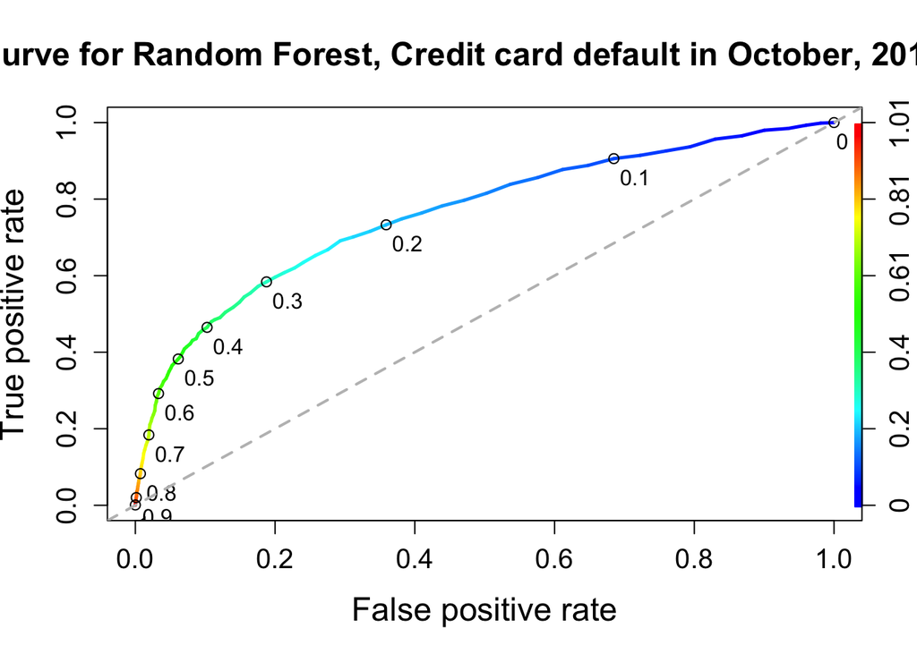

```r
#quartz()
par(cex.axis=1.25, cex.lab=1.5, cex.main=1.5)
plot(bag.perf, colorize=TRUE,lwd=2.5, print.cutoffs.at=seq(0,1,by=0.1), text.adj=c(-0.2,1.7),
     main="ROC Curve for Random Forest, Credit card default in October, 2015, Taiwan")
abline(a=0,b=1,lwd=2,lty=2,col="gray")
```

Look at false positives and false negatives based on designated cutoff

```r
#library(caret)
#pick a cutoff in the elbow of the ROC curve
cutoff=c(0.8,0.2)
set.seed(123)
#bag2 = randomForest(as.factor(default) ~., data=train, mtry=9, ntree=100, importance=TRUE, cutoff=cutoff)
pred2 <- predict(bag2, newdata=CV)
CrossTable(pred2, CV$default)
```

```
##
##
##    Cell Contents
## |-------------------------|
## |                       N |
## | Chi-square contribution |
## |           N / Row Total |
## |           N / Col Total |
## |         N / Table Total |
## |-------------------------|
##
##
## Total Observations in Table:  6000
##
##
##              | CV$default
##        pred2 |         0 |         1 | Row Total |
## -------------|-----------|-----------|-----------|
##            0 |      3037 |       374 |      3411 |
##              |    49.048 |   178.203 |           |
##              |     0.890 |     0.110 |     0.569 |
##              |     0.645 |     0.289 |           |
##              |     0.506 |     0.062 |           |
## -------------|-----------|-----------|-----------|
##            1 |      1668 |       921 |      2589 |
##              |    64.621 |   234.782 |           |
##              |     0.644 |     0.356 |     0.431 |
##              |     0.355 |     0.711 |           |
##              |     0.278 |     0.153 |           |
## -------------|-----------|-----------|-----------|
## Column Total |      4705 |      1295 |      6000 |
##              |     0.784 |     0.216 |           |
## -------------|-----------|-----------|-----------|
##
##
```

```r
specificity(pred2, CV$default, negative = levels(CV$default)[1])
```

```
## [1] 0.6454835
```

```r
sensitivity(pred2, CV$default, positive = levels(CV$default)[-1])
```

```
## [1] 0.7111969
```

```r
#Trying different cutoffs can addjust  sensitivity and specificity to desired levels of false positives vs false negatives
cutoff=c(0.7,0.3)
set.seed(123)
#bag3 = randomForest(as.factor(default) ~., data=train, mtry=9, ntree=100, importance=TRUE, cutoff=cutoff)
pred3 <- predict(bag3, newdata=CV)
CrossTable(pred3, CV$default)
```

```
##
##
##    Cell Contents
## |-------------------------|
## |                       N |
## | Chi-square contribution |
## |           N / Row Total |
## |           N / Col Total |
## |         N / Table Total |
## |-------------------------|
##
##
## Total Observations in Table:  6000
##
##
##              | CV$default
##        pred3 |         0 |         1 | Row Total |
## -------------|-----------|-----------|-----------|
##            0 |      3839 |       545 |      4384 |
##              |    46.824 |   170.122 |           |
##              |     0.876 |     0.124 |     0.731 |
##              |     0.816 |     0.421 |           |
##              |     0.640 |     0.091 |           |
## -------------|-----------|-----------|-----------|
##            1 |       866 |       750 |      1616 |
##              |   127.028 |   461.520 |           |
##              |     0.536 |     0.464 |     0.269 |
##              |     0.184 |     0.579 |           |
##              |     0.144 |     0.125 |           |
## -------------|-----------|-----------|-----------|
## Column Total |      4705 |      1295 |      6000 |
##              |     0.784 |     0.216 |           |
## -------------|-----------|-----------|-----------|
##
##
```

```r
specificity(pred3, CV$default, negative = levels(CV$default)[1])
```

```
## [1] 0.8159405
```

```r
sensitivity(pred3, CV$default, positive = levels(CV$default)[-1])
```

```
## [1] 0.5791506
```

Finally, report out the model performance on the test data:

```r
trainall<- rbind(train,CV) #traina nd CV datasets can be combined to create a larger dataset for training

cutoff=c(0.7,0.3)
set.seed(123)
#bag5 = randomForest(as.factor(default) ~., data=trainall, mtry=9, ntree=100, importance=TRUE, cutoff=cutoff)
pred5 <- predict(bag5, newdata=test)
CrossTable(pred5, test$default)
```

```
##
##
##    Cell Contents
## |-------------------------|
## |                       N |
## | Chi-square contribution |
## |           N / Row Total |
## |           N / Col Total |
## |         N / Table Total |
## |-------------------------|
##
##
## Total Observations in Table:  6000
##
##
##              | test$default
##        pred5 |         0 |         1 | Row Total |
## -------------|-----------|-----------|-----------|
##            0 |      3886 |       580 |      4466 |
##              |    54.705 |   186.110 |           |
##              |     0.870 |     0.130 |     0.744 |
##              |     0.838 |     0.426 |           |
##              |     0.648 |     0.097 |           |
## -------------|-----------|-----------|-----------|
##            1 |       751 |       783 |      1534 |
##              |   159.265 |   541.829 |           |
##              |     0.490 |     0.510 |     0.256 |
##              |     0.162 |     0.574 |           |
##              |     0.125 |     0.131 |           |
## -------------|-----------|-----------|-----------|
## Column Total |      4637 |      1363 |      6000 |
##              |     0.773 |     0.227 |           |
## -------------|-----------|-----------|-----------|
##
##
```

```r
specificity(pred5, test$default, negative = levels(test$default)[1])
```

```
## [1] 0.8380418
```

```r
sensitivity(pred5, test$default, positive = levels(test$default)[-1])
```

```
## [1] 0.5744681
```